# B.1: Police Violence and Racial Inequity

2022-11-15

## Overview

This is a brief report identifying any significant patterns regarding police violence, criminal activity, racial equity, and other factors influencing these activities in the United state. The data reveals the statistics of arrests, fatal encounters and death of victims that are categorized by racial and gender identity.

| Year | Total Arrests | Male Arrests Percentage | Female Arrests Percentage | White Arrests | Black Arrests | Asian & Pacific Islander Arrests | American Indian Arrests | Common Victim Death Cause | Number of Victim Deaths by Cause | Percentage of Deaths by Cause | Common Police Death Cause | Number of Police Deaths by Cause | Percentage of Deaths by Cause |
| --- | --- | --- | --- | --- | --- | --- | --- | --- | --- | --- | --- | --- | --- |
| 2000 | 8964238 | 80 | 20 | 5936787 | 2777832 | 89504 | 109724 | Gunshot | 546 | 64 | Gunfire | 53 | 31 |
| 2001 | 9040623 | 80 | 20 | 6040999 | 2780997 | 94818 | 105814 | Gunshot | 662 | 72 | Terrorist attack | 73 | 30 |
| 2002 | 8740017 | 79 | 21 | 6073381 | 2439149 | 95048 | 113785 | Gunshot | 668 | 68 | Gunfire | 58 | 35 |
| 2003 | 8644571 | 78 | 22 | 6045151 | 2372335 | 91661 | 113640 | Gunshot | 715 | 68 | Gunfire | 50 | 32 |
| 2004 | 8893755 | 78 | 22 | 6272269 | 2389571 | 91957 | 115102 | Gunshot | 739 | 71 | Gunfire | 59 | 34 |
| 2005 | 9242920 | 78 | 22 | 6378161 | 2481451 | 92406 | 120216 | Gunshot | 798 | 68 | Gunfire | 55 | 32 |
| 2006 | 9219299 | 78 | 22 | 6452057 | 2520154 | 94597 | 118728 | Gunshot | 845 | 67 | Gunfire | 52 | 32 |
| 2007 | 9419587 | 77 | 23 | 6585570 | 2576509 | 99473 | 125161 | Gunshot | 834 | 66 | Gunfire | 69 | 32 |
| 2008 | 9433013 | 77 | 23 | 6570634 | 2592467 | 101744 | 125951 | Gunshot | 822 | 68 | Gunfire | 42 | 25 |
| 2009 | 9524037 | 76 | 24 | 6633338 | 2603987 | 105391 | 133547 | Gunshot | 902 | 72 | Gunfire | 51 | 34 |
| 2010 | 9221217 | 76 | 24 | 6430331 | 2510169 | 107111 | 132945 | Gunshot | 919 | 71 | Gunfire | 62 | 34 |
| 2011 | 8748808 | 75 | 25 | 6079270 | 2395931 | 103353 | 133819 | Gunshot | 1043 | 74 | Gunfire | 70 | 36 |
| 2012 | 8818851 | 75 | 25 | 6103336 | 2419925 | 128544 | 127594 | Gunshot | 1118 | 75 | Gunfire | 54 | 34 |
| 2013 | 8581052 | 75 | 25 | 5993921 | 2272474 | 106360 | 129270 | Gunshot | 1181 | 66 | Gunfire | 35 | 25 |
| 2014 | 8169720 | 74 | 26 | 5681236 | 2198711 | 108419 | 126248 | Gunshot | 1101 | 64 | Gunfire | 52 | 32 |
| 2015 | 8031139 | 74 | 26 | 5583910 | 2100742 | 121923 | 170330 | Gunshot | 1162 | 72 | Gunfire | 43 | 27 |
| 2016 | 8075886 | 74 | 26 | 5618031 | 2116764 | 120486 | 164506 | Gunshot | 1278 | 80 | Gunfire | 27 | 36 |

## Plots

Reported cases of police killings (by shooting) across race, gender and age. These charts cover the years 2015-2020.

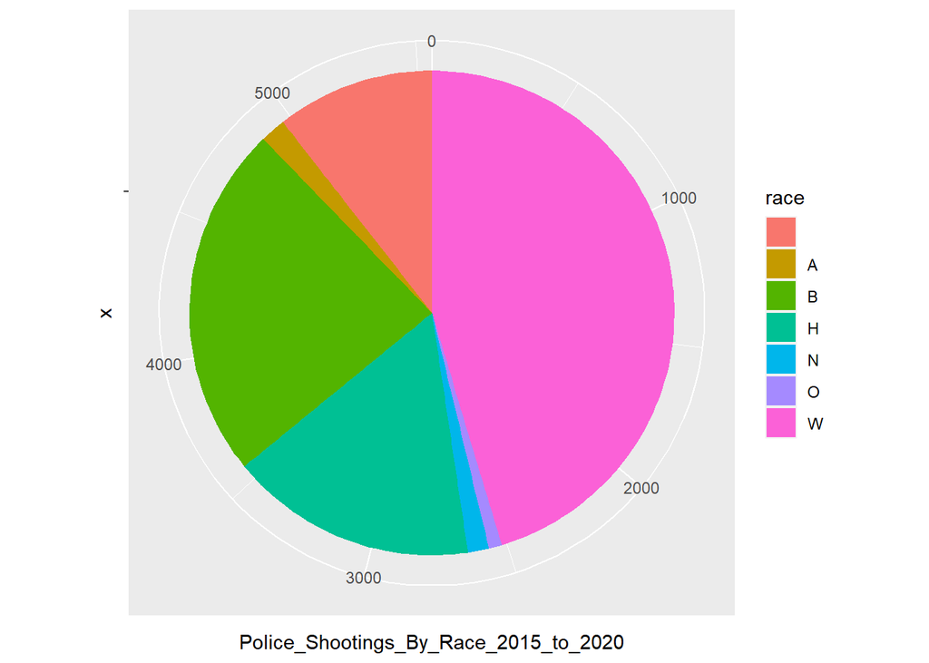

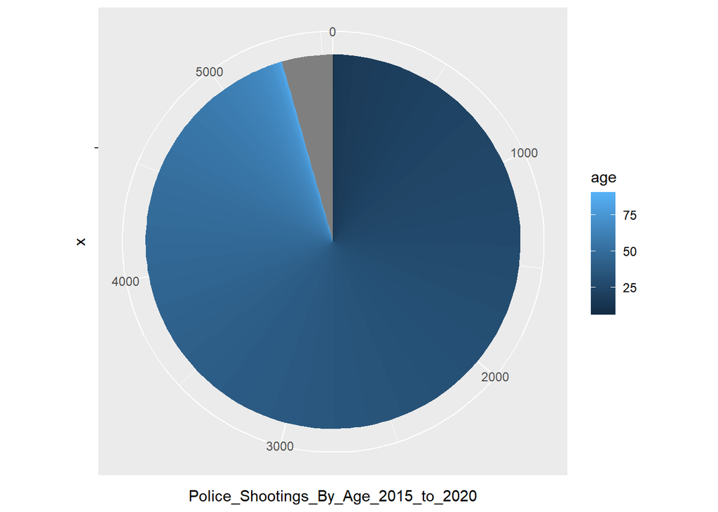

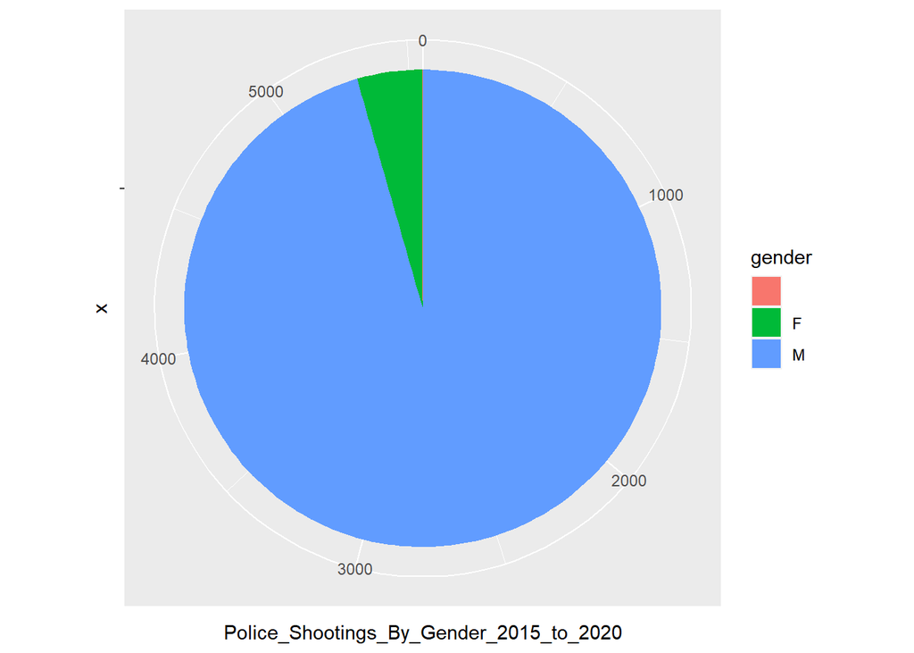

All three of the pie charts represent reported cases of police killings (by shooting) across three metrics: race, gender and age. These charts cover the years 2015-2020. As shown by the pies, white people have been killed the most by police. However, white people make up 75% of the U.S. population, while Black people make up only 13%. Because of this, it’s clear to see that Black victims are killed at a disproportionate rate compared to white victims. When looking at the age graph, it’s clear that younger people are killed much more by the police. Similarly, the gender pie chart shows men are much more likely to die at the hands of the police.

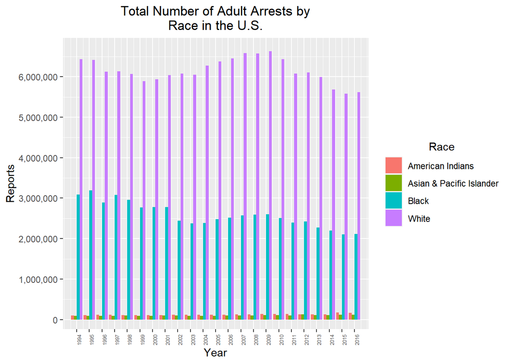

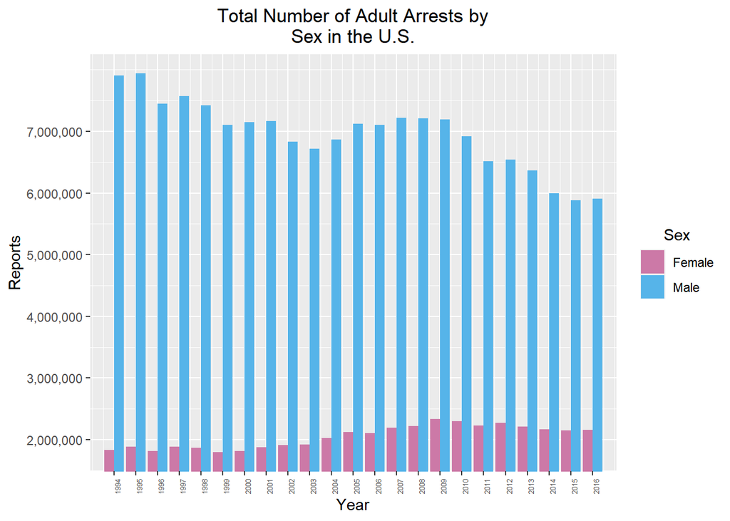

Both of these graphs illustrate the total number of adult arrests reported in the U.S. by the agencies from 1994-2016, with one graph representing the proportions of arrests by gender and the other graph showing the proportions by race. From these bar graphs,there is a hugely noticeable gap between the division of arrests against males versus females, and a stronger association of arrests being targeted towards the White & Black community as opposed to the Asian, Pacific Islander, and American Indians.

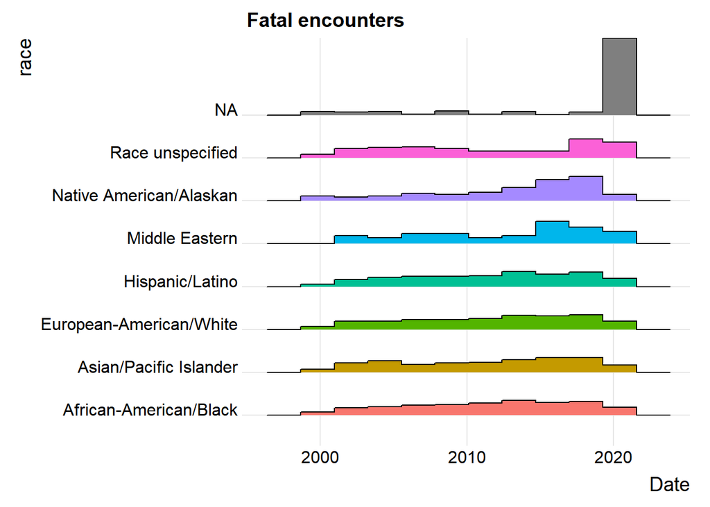

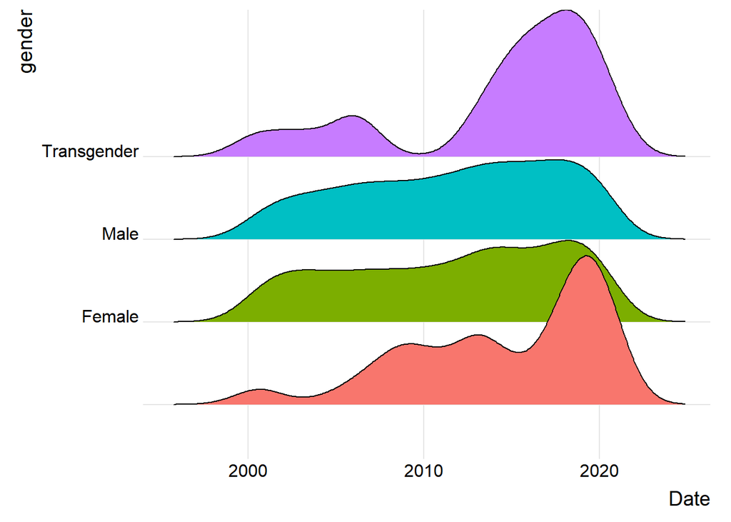

This graph illustrate the racial statistics and statistics of race and gender for fatal encounters in the United States from 1/1/00 to 8/18/20.The fatal encounters of Native American/Alaskan had been increasing while that of Middle Eastern had been decreasing in recent years. Moreover the number of Transgender fatal encounters has rapidly increased compared to other genders.